# Roulette Simulation

### September 6, 2021

# 1 Introduction

The purpose of this blog post is to understand the Martingale strategy for playing roulette. The Martingale strategy tries to shift the odds that the player will always end up in the positive, something that casinos try their best to avoid. We will dive into this strategy to see whether it truly works and if changing variables can help the player win more money.

# 1.1 Background

Roulette is a game that dates back to 18th century France. It is a wheel that is made up of 38 spaces (0, 00, and 1 through 36) and 3 colors (18 red, 18 black, and 2 green to ensure that the odds are in the house’s favor). The types of bets that a player can be broken down into 2 different categories, inside and outside. Inside bets are for betting on the numbers and can used to couple up to 4 numbers on a single bet. Outside bets are for betting on the color, low or high, even or odd, etc. The Martingale strategy starts by placing a minimum bet (usually $1, but can change) on red. If the roulette wheel produces a red spin, the player collects their winnings and continues to bet one dollar on red. If the player loses their bet, they then double their bet until the roulette wheel hits red again. This strategy, when done correctly, ensures that the player will always end in the positive, but how much money can we win if we change the variables?

# 2 Methods

### Simulating One Wheel Spin of Roulette

```r
library(dbplyr)
one_play <- function(state){

  # Wager
  proposed_wager <- ifelse(state$previous_win, 1, 2*state$previous_wager)
  wager <- min(proposed_wager, state$M, state$B)

  # Spin of the wheel
  red <- rbinom(1,1,18/38)

  # Update state
  state$plays <- state$plays + 1
  state$previous_wager <- wager
  if(red){
    # WIN
    state$B <- state$B + wager
    state$previous_win <- TRUE
  }else{
    # LOSE
    state$B <- state$B - wager
    state$previous_win <- FALSE
  }
  state
}
```

Here, we need to create a function called *one_play* that will allow us to run a simulation of one roulette spin. Using *proposed_wager*, we are able to show that if we win, we continue to gamble $1, but if we lose, we double the bet until we win again. We create the simulation of the roulette wheel landing on red by using the *rbinom* function, a function that randomly assigns wins and loses using the odds of 18/38 (the true odds landing on red.) We then use this function to test whether or not we win the round, or if we need to double the bet on the next roll. We also need to update the state of the game after every wheel spin, so we see above in the chunk of code denoted with `# Update state` that shows us if we land on red we win, so we add our wager to our initial budget and *previous_win* is TRUE. That is foll0wed by an else statement that represents us losing, so it deducts the wager from the initial budget and sets *previous_win* to FALSE and doubles the wager.

### Stopping Rule

```r
#' Stopping rule
stop_play <- function(state){
  if(state$B <= 0) return(TRUE)
  if(state$plays >= state$L) return(TRUE)
  if(state$B >= state$W) return(TRUE)
  FALSE
}
```

We use this *stop_play* function to tell the simulation when to stop based on multiple factors. “W” represents that the player has W dollars and the gambling must end, “L” represents the amount of roulette wheel spins limit that the player sets for themselves, and “B” represents that the player has gone bankrupt and must walk away from gambling.

### Setting the Martingale Strategy

```r
#' Play roulette to either bankruptcy, success, or play limits
one_series <- function(
  B = 200
  , W = 300
  , L = 1000
  , M = 100
){

  # initial state
  state <- list(
    B = B
    , W = W
    , L = L
    , M = M
    , plays = 0
    , previous_wager = 0
    , previous_win = TRUE
  )

  # vector to store budget over series of plays
  budget <- rep(NA, L)

  # For loop of plays
  for(i in 1:L){
    new_state <- state %>% one_play
    budget[i] <- new_state$B
    if(new_state %>% stop_play){
      return(budget[1:i])
    }
    state <- new_state
  }
  budget
}
```

Now that we have a function that allows us to “spin” the roulette wheel once, we need another function that allows us to simulate the Martingale strategy. We set parameters (described below) to allow us to “sit down” at the table and start gambling.

As we can see in the initial state:

| Parameter | Description |
| --- | --- |
| B | Initial Budget |
| W | Budget threshold for stopping |
| L | Maximum plays |
| M | Casino maximum |

### Running a Simulation

```r
# helper function
get_last <- function(x) x[length(x)]


# Simulation
walk_out_money <- rep(NA, 10000)
for(j in seq_along(walk_out_money)){
  walk_out_money[j] <- one_series(B = 200, W = 300, L = 1000, M = 100) %>% get_last
}
```

The code above is our actual simulation. We use the loop `for(j in seq_along(walk_out_money))` to simulate using the Martingale strategy until each stopping point 10000 times. Our default settings are that we start with $200, our winnings threshold is $300 ($200 that we started with plus $100 in winnings), a maximum plays limit at 1000 per round, and a casino maximum bet of $100. Our *walk_out_money* value stores the amount of cash we walk away from the table with in each simulation, $0 (we ran out of money) or $300 (we hit our winnings threshold.) This value is very important when computing how well the Martingale strategy will work when gambling at a roulette table.

### Average Plays in Martingale Strategy

```r
total_plays <- rep(NA, 10000)
for(j in seq_along(walk_out_money)){
  total_plays[j] <- length(one_series(B = 200, W = 300, L = 1000, M = 100)) %>%
    get_last}

mean(total_plays)
```

```
## [1] 202.8944
```

# 3 Results

### Walk Out Money Distribution

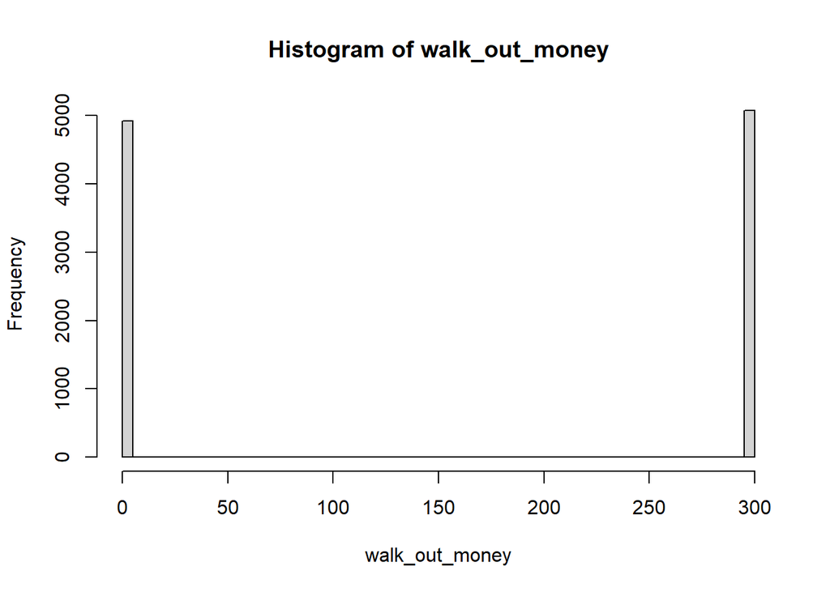

```r
hist(walk_out_money, breaks = 100)
```

Using our *walk_out_money* value (described above) we want to see the distribution of our simulations and see how well we did. The histogram above looks like a goal post, but it is correct because the only values we can achieve (because the low starting budget and high number of maximum plays) are losing everything and walking out with $0 or hitting our winnings threshold and walking away with $300 ($100 in earnings plus the $200 initial budget.)

### Estimated Probability of Walking Out With Extra Cash

```r
mean(walk_out_money > 200)
```

```
## [1] 0.5078
```

Here, we use the *mean()* function to test the probability of walking away with extra cash. We must use `walk_out_money > 200`, specifically the “> 200” to return values of *TRUE* or *FALSE* for all of our ending values stored in *walk_out_money*. Based on our results and using the parameters we set, we have a slightly better than 50% chance of walking away with extra cash.

### Estimated Earnings

```r
mean(walk_out_money - 200)
```

```
## [1] -47.6763
```

# 3.1 Limitations

### Example

Note that we will use -$1000 for the initial budget *B* and calculate our walk out money distribution. Although the histogram below did its job in showing us the correct distribution of our walk out money, it is impossible to start with an initial budget of -$1,000.

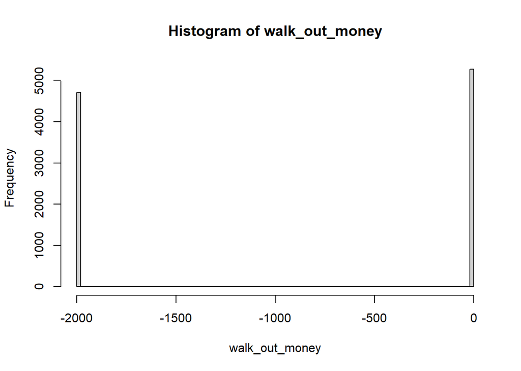

```r
walk_out_money <- rep(NA, 10000)
for(j in seq_along(walk_out_money)){
  walk_out_money[j] <- one_series(B = -1000, W = 300, L = 1000, M = 100) %>% get_last
}

# Walk out money distribution
hist(walk_out_money, breaks = 100)
```

# 4 Changing Parameters

When we ran the above simulation, we set the parameters at a $200 budget, a $300 winnings threshold, 1000 plays, and with a maximum casino bet at $100. These numbers are fairly standard for anyone walking into a casino, we want to see whether one change can make a difference in how much money we walk away from the table with.

### Starting Budget

Here, we will test whether increasing the starting budget will increase our probability of walking out with extra cash. We will increase B to $500 and W to $600 to keep the $100 winnings goal.

```r
walk_out_money <- rep(NA, 10000)
for(j in seq_along(walk_out_money)){
  walk_out_money[j] <- one_series(B = 500, W = 600, L = 1000, M = 100) %>% get_last
}

mean(walk_out_money > 500)
```

```
## [1] 0.6281
```

Holding all other parameters equal, we shockingly have much better odds of walking out with extra cash when we increased the starting budget from $200 to $500.

### Winnings Threshold

We can also test if changing the winnings threshold will affect our odds of walking away with extra cash, so here we changed the winnings threshold parameter, W, to $250 to represent a $50 winnings goal.

```r
walk_out_money <- rep(NA, 10000)
for(j in seq_along(walk_out_money)){
  walk_out_money[j] <- one_series(B = 200, W = 250, L = 1000, M = 100) %>% get_last
}
mean(walk_out_money > 200)
```

```
## [1] 0.6955
```

Unsurprisingly, we see a noticeable increase in probability of walking out with extra cash when we decreased the winnings threshold in half.

### Number of Plays

I touched on this before, but the high number of plays that we used above was the biggest issue in our simulation. We received values that were only $0 or the winnings threshold, so I wanted to test what would happen if put the maximum number of plays value at something realistic. I set the value to 100 plays and see the distribution is more representative of true outcomes.

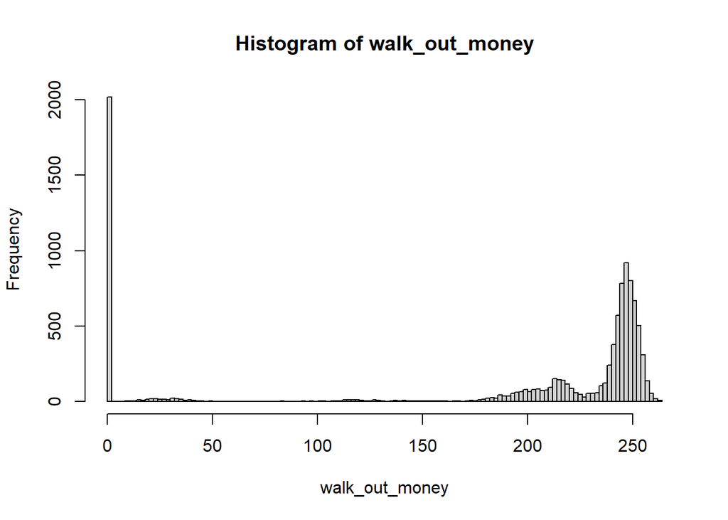

```r
walk_out_money <- rep(NA, 10000)
for(j in seq_along(walk_out_money)){
  walk_out_money[j] <- one_series(B = 200, W = 300, L = 100, M = 100) %>% get_last
}
hist(walk_out_money, breaks = 100)
```

This histogram depicts a better distribution of possibilities than the one run in the simulation above. Although the most common outcome is leaving the table with $0, we can see other values represented in the graph which gives us a more realistic view at using the Martingale strategy.

# 5 Conclusions

Based on the simulation we ran, if we were to use the Martingale strategy while playing roulette we would need to test many different combinations of the parameters we used to be successful. The simulation we ran with an initial budget of $200, a winnings threshold of $300 ($100 in winnings plus the $200 initial budget), 1000 spin limit, and a casino maximum bet of $100, produced results for us, but we unrealistic. Having such a high maximum number of plays combined with a relatively low starting budget only allowed us to lose all of our money or hit our winnings threshold. We saw a few limitations on our simulation and I believe that it proved the Martingale strategy to be a fraud. It is not a good way to spend your time at the roulette table or a smart way to spend your money. There is simply no way of cheating the casino that does not involve counting cards. My advice; go to the casino, have fun, and never think that you can out-smart the house because you cannot.